# Reproducible Research: Peer Assessment 1

## Loading and preprocessing the data

```r
if(!file.exists('activity.csv')){
    unzip('activity.zip')
}
raw_data <- read.csv('activity.csv')
data = raw_data
```

Now we have the data in data variable. Lets checkout the data a bit

```r
head(data, 3)
```

```
##   steps       date interval
## 1    NA 2012-10-01        0
## 2    NA 2012-10-01        5
## 3    NA 2012-10-01       10
```

## What is mean total number of steps taken per day?

```r
# add hour / min detail
# so at interval 2355 the time is 23:55 or 5 minuters to midnight.
data <- mutate(data, hour = interval %/% 100, minute = interval %% 100)
```

*For this part of the assignment, you can ignore the missing values in the dataset.*

```r
dataNoNa <- data[complete.cases(data), ]
```

*Calculate the total number of steps taken per day*

```r
totalSteps  <- aggregate(steps ~ date, dataNoNa, sum)
```

*If you do not understand the difference between a histogram and a barplot, research the difference between them. Make a histogram of the total number of steps taken each day.*

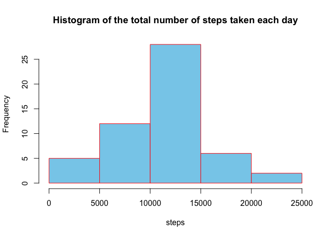

```r
hist(totalSteps$steps, xlab="steps",ylab="Frequency",col="skyblue",border="red",
     main="Histogram of the total number of steps taken each day")
```

*Calculate and report the mean and median of the total number of steps taken per day*

```r
mean(totalSteps$steps) ## get the mean
```

```
## [1] 10766.19
```

```r
median(totalSteps$steps) ## get the median
```

```
## [1] 10765
```

## What is the average daily activity pattern?

*Make a time series plot (i.e. 𝚝𝚢𝚙𝚎 = “𝚕”) of the 5-minute interval (x-axis) and the average number of steps taken, averaged across all days (y-axis)*

```r
stepsInterval  <- aggregate(steps ~ interval, dataNoNa, mean)
```

We have the average value for each interval. so for all values of interval 1000 we have the mean for all dates. Now lets make a plot of this.

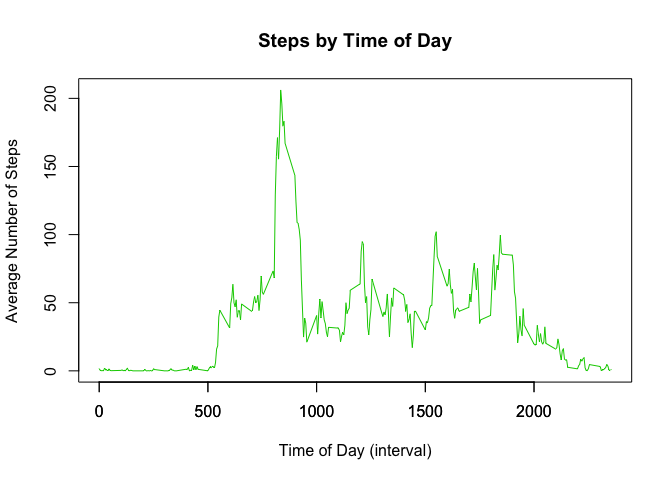

```r
plot(stepsInterval$interval, stepsInterval$steps, type="l", col=3, main="Steps by Time of Day",
     xlab="Time of Day (interval)", ylab="Average Number of Steps", xlim=c(0,2355))
axis(side=1, at=seq(0, 2400, by=500))
```

?*Which 5-minute interval, on average across all the days in the dataset, contains the maximum number of steps?*

```r
int = which.max(stepsInterval$steps)
```

```r
colMax <- max(stepsInterval$steps)
```

## Imputing missing values

*Note that there are a number of days/intervals where there are missing values (coded as 𝙽𝙰). The presence of missing days may introduce bias into some calculations or summaries of the data.*

*Calculate and report the total number of missing values in the dataset (i.e. the total number of rows with NA’s*

```r
sum(is.na(data[,1]))
```

```
## [1] 2304
```

```r
nrow(data[!complete.cases(data), ])
```

```
## [1] 2304
```

*Devise a strategy for filling in all of the missing values in the dataset. The strategy does not need to be sophisticated. For example, you could use the mean/median for that day, or the mean for that 5-minute interval, etc.*

```r
imp_data = raw_data
```

**Let’s fill in the NA with the aveage**

*Create a new dataset that is equal to the original dataset but with the missing data filled in.*

```r
for (i in 1:nrow(imp_data)) {
  if (is.na(imp_data$steps[i])) {
    interval_value <- imp_data$interval[i]
    steps_value <- stepsInterval[
      stepsInterval$interval == interval_value,]
    imp_data$steps[i] <- steps_value$steps
  }
}
```

```r
imp_steps  <- aggregate(steps ~ date, imp_data, sum)
```

*If you do not understand the difference between a histogram and a barplot, research the difference between them. Make a histogram of the total number of steps taken each day.*

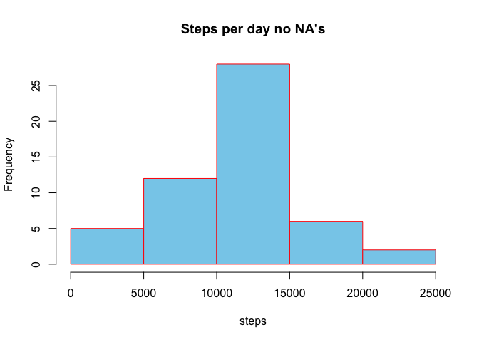

```r
hist(totalSteps$steps, xlab="steps",ylab="Frequency",col="skyblue",border="red",
     main="Steps per day no NA's")
```

*What is the impact of imputing missing data on the estimates of the total daily number of steps?*

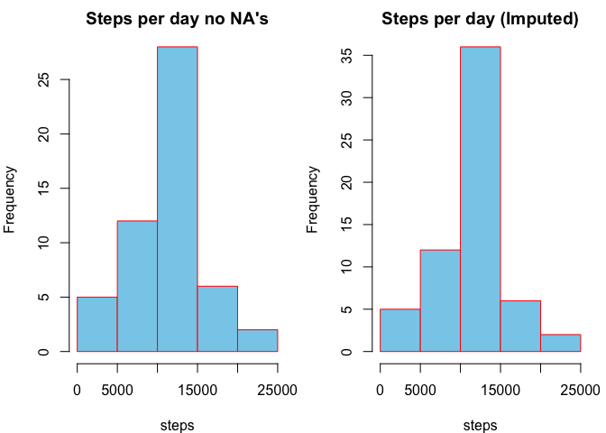

```r
par(mfrow = c(1, 2), mar = c(4, 4, 2, 1))
hist(totalSteps$steps, xlab="steps",ylab="Frequency",col="skyblue",border="red",
     main="Steps per day no NA's")
hist(imp_steps$steps, xlab="steps",ylab="Frequency",col="skyblue",border="red",
     main="Steps per day (Imputed)")
```

## Are there differences in activity patterns between weekdays and weekends?

*For this part the 𝚠𝚎𝚎𝚔𝚍𝚊𝚢𝚜() function may be of some help here. Use the dataset with the filled-in missing values for this part.*

*Create a new factor variable in the dataset with two levels – “weekday” and “weekend” indicating whether a given date is a weekday or weekend day.*

```r
week_day <- function(date_val) { ##week day function for apply
    wd <- weekdays(as.Date(date_val, '%Y-%m-%d'))
    if  (!(wd == 'Saturday' || wd == 'Sunday')) {
        x <- 'Weekday'
    } else {
        x <- 'Weekend'
    }
    x
}
data$day_type <- as.factor(sapply(data$date, week_day))
```

make two sets of data, one for weekends and one for work week.

```r
dataNoNa <- data[complete.cases(data), ]

workWeek <- subset(dataNoNa, day_type == "Weekday")
weekEnd <- subset(dataNoNa, day_type == "Weekend")

str(workWeek)
```

```
## 'data.frame':    11232 obs. of  6 variables:
##  $ steps   : int  0 0 0 0 0 0 0 0 0 0 ...
##  $ date    : Factor w/ 61 levels "2012-10-01","2012-10-02",..: 2 2 2 2 2 2 2 2 2 2 ...
##  $ interval: int  0 5 10 15 20 25 30 35 40 45 ...
##  $ hour    : num  0 0 0 0 0 0 0 0 0 0 ...
##  $ minute  : num  0 5 10 15 20 25 30 35 40 45 ...
##  $ day_type: Factor w/ 2 levels "Weekday","Weekend": 1 1 1 1 1 1 1 1 1 1 ...
```

```r
str(weekEnd)
```

```
## 'data.frame':    4032 obs. of  6 variables:
##  $ steps   : int  0 0 0 0 0 0 0 0 0 0 ...
##  $ date    : Factor w/ 61 levels "2012-10-01","2012-10-02",..: 6 6 6 6 6 6 6 6 6 6 ...
##  $ interval: int  0 5 10 15 20 25 30 35 40 45 ...
##  $ hour    : num  0 0 0 0 0 0 0 0 0 0 ...
##  $ minute  : num  0 5 10 15 20 25 30 35 40 45 ...
##  $ day_type: Factor w/ 2 levels "Weekday","Weekend": 2 2 2 2 2 2 2 2 2 2 ...
```

*Make a panel plot containing a time series plot (i.e. 𝚝𝚢𝚙𝚎 = “𝚕”) of the 5-minute interval (x-axis) and the average number of steps taken, averaged across all weekday days or weekend days (y-axis). See the README file in the GitHub repository to see an example of what this plot should look like using simulated data.*

```r
wrkWSteps  <- aggregate(steps ~ interval, workWeek, mean)
wkendSteps <- aggregate(steps ~ interval, weekEnd, mean)
```

Draw the plot

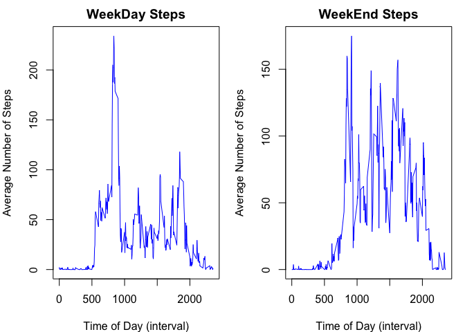

```r
par(mfrow = c(1, 2), mar = c(4, 4, 2, 1))
plot(wrkWSteps$interval, wrkWSteps$steps, type="l", col=4, main="WeekDay Steps",
     xlab="Time of Day (interval)", ylab="Average Number of Steps")
plot(wkendSteps$interval, wkendSteps$steps, type="l", col=4, main="WeekEnd Steps",
     xlab="Time of Day (interval)", ylab="Average Number of Steps")
```

**We notice that this person walks more often throughout the weekend. Perhaps they exercise in the morning and sit at a desk during the day?**